# Problem Set 05

Week 04

```r
library(tidyverse)
library(ggdist)
library(distributional)
library(cowplot)
```

# Learning objectives

- Conduct a hypothesis test for a single proportion and a single mean
- Articulate the role sample size plays in hypothesis testing
- Investigate the relationship between critical regions, alpha (significance) levels, and p-values.
- Determine the significance level and Type II error rate of a test
- Reflect on the proof that p-values are uniformly distributed (under $H_0$) and the fact $P(p_v < \alpha) = \alpha$.

# Exercises

1. Public health officials in a large city decided that if compelling evidence could be presented that less than 90% of children under six years of age in the city had received the DPT vaccine, then they would carry out an expensive immunization program throughout the city. A random sample was taken of 537 children under six years of age in the city; of these 460 had been immunized for DPT.
   1. State an appropriate set of hypotheses for this scenario.
   2. Define a critical region for which you will reject the null hypothesis at most 1% of the time when it is true.
   3. Compute a relevant point estimate and test statistic.
   4. State your conclusion for the hypothesis test, and your recommendation about the immunization program.
2. Return to the right front tire scenario. Suppose that 30% of the people in a random sample from a population select the right front tire.
   1. Is 30% a population parameter, sample statistic, test statistic, or critical value? Explain.
   2. What more information do you need to conduct a hypothesis test?
   3. Write out the hypotheses being tested.
   4. Suppose that the sample size is n = 100. Determine the value of the test statistic.
   5. What critical value (on the scale of $\hat{p}$) is needed for a significance level of 0.05 in this case? What conclusion do you draw from the hypothesis test? Explain your reasoning.
   6. Repeat d & e for a sample size of n = 500.
   7. Explain what the figure below is demonstrating as best you can, and use it to summarize the role of sample size on these hypothesis tests. Questions to consider: What notation would you use to lable the center of the distributions? What about the shaded region? Is the critical region displayed on this visualization?

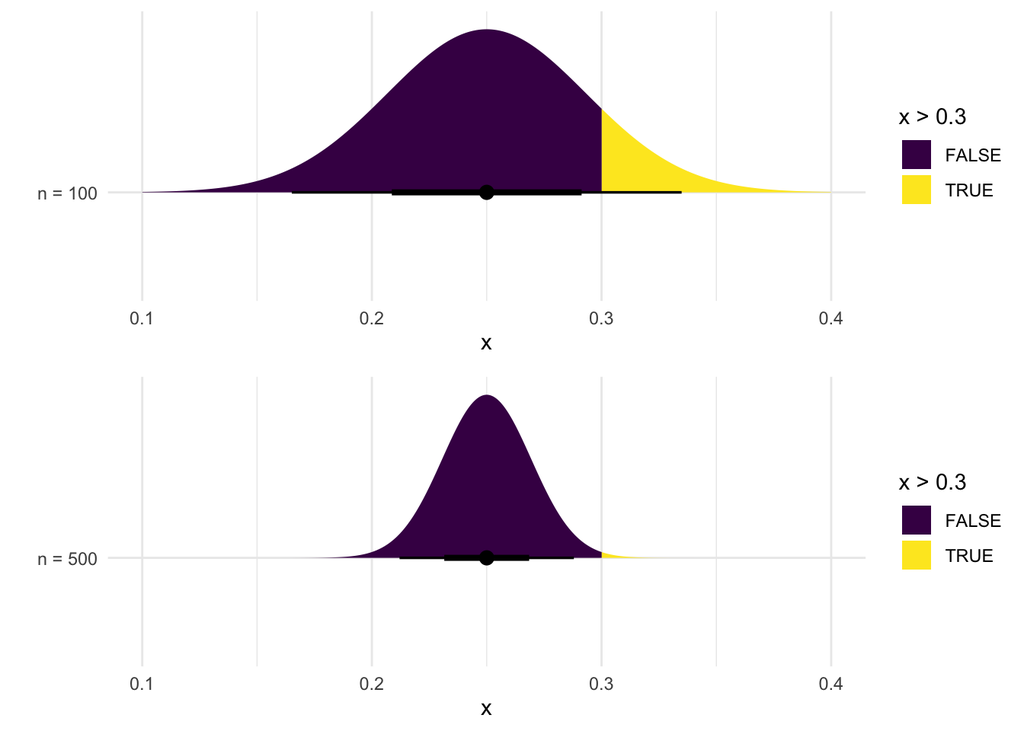

3. Suppose that we design a study in order to test $H_0: p = 0.7$ against $H_A: p > 0.7$, and we determine a sample size of $n = 150$ is needed. We decide to reject $H_0$ and accept $H_A$ if and only if $\hat{p} \geq .75$.
   1. Determine the significance level $\alpha$ of this test. *Drawing a picture may help*
   2. Find the probability of the Type II error if, in fact, $p = 0.77$. *Drawing a picture may help*
4. Assume you are testing the hypotheses $H_0: \mu = \mu_0$ vs. $H_A: \mu > \mu_0$ and that $\sigma$ is known. Define a critical region $C$ such that if $\overline{X} \in C$, you reject $H_0$ at a significance level of $\alpha$. That is, define an expression for a critical value that will result in a Type I error rate of $\alpha$. Or stated yet another way, your region $C$ should be defined such that $P(\overline{X} \in C |H_0 \text{ true}) = \alpha$. *Hint: Start with the following probability statement are rearrange*
   $$P\left(\frac{\overline{X} -
   \mu}{\sigma/\sqrt{n}}>z_{\alpha}\right) = \alpha$$
5. [HTZ: 8.1-5] The mean birth weight in the United States is $\mu = 3315$, with a standard deviation of $\sigma = 575$. Let $X$ equal the birth weight in grams in Jerusalem. Conduct a hypothesis test to investigate whether the average birth weight in Jerusalem is lower than in the U.S.
   1. State the null and alternative hypotheses
   2. Define a critical region that has a significance level of $\alpha = 0.05$.
   3. If the random sample of $n = 30$ yielded $\overline{X} = 3189$ and $s = 488$, what would be your conclusion?
   4. What is the p-value of your test?

## Simulation exploration

The `NHANES` dataset in the `NHANES` package contains data collected by the US National Center for Health Statistics (NCHS) on 10,000 individuals from 2009 - 2012. For the purposes of this exercise, we will treat this as a **population** dataset.

Our variable of interest is `Pulse`, which is a numeric variable for a person’s 60 second pulse rate. For the purposes of this demonstration, we will filter out people for whom `Pulse` was not recorded and restrict our population to adults age 18+. We’ll consider the resulting dataset `nhanes` to be our population of interest.

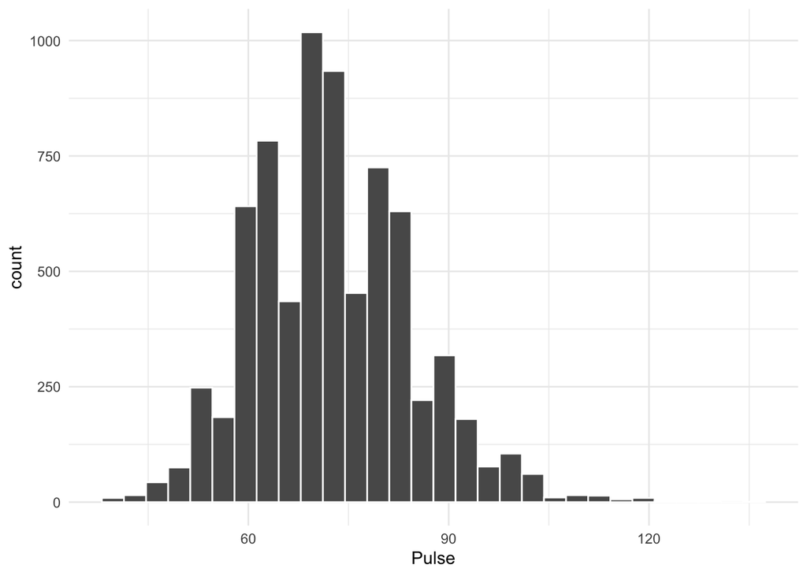

```r
library(NHANES)
library(infer)

nhanes <- NHANES %>%
  filter(!is.na(Pulse), Age >= 18)

ggplot(nhanes, aes(x = Pulse)) +
  geom_histogram(color = "white") +
  theme_minimal()
```

The average pulse among U.S. adults is $\mu = 72.57$

```r
mu <- mean(nhanes$Pulse)
mu
```

```
## [1] 72.57095
```

Note, not every random sample from this population will produce a sample statistic of $\bar{x} = 72.57$; there will be sampling variability. We will use simulations to explore this sampling variability and its relationship to hypothesis testing. Before conducting the simulations:

6. Consider the hypothesis test $H_0: \mu = 72.57$ vs. $H_A: \mu \neq 72.57$ with $\alpha = 0.05$.
   1. Is the null hypothesis true in this case? *Note, we won’t know this in real life! But we are using a scenario where we know the truth (we have the whole population) to demonstrate/verify the mathematical properties.*
   2. Recall the test statistic is given by $T = \frac{\bar{x} - \mu}{s/\sqrt{n}}$, where $\bar{x}$ is the mean pulse observed in the sample, $s$ the standard deviation observed in the sample, and $n$ is the sample size. If we were to draw 10,000 random samples from the `nhanes` population, how many of them would you expect to result in a test statistic $T > 1.96$? What about $T < 1.5$?
   3. What is the appropriate critical region for this $\alpha = 0.05$ two-sided test? That is, for which values of the test statistic $T$ should $H_0$ be rejected?
   4. Will a test statistic that falls in the critical region lead to a correct or incorrect conclusion to the hypothesis test in this case?

The following code draws 10,000 random samples of size 100 and computes the sample mean and sample standard deviation in each and then visualizes the sampling distribution of the sample mean.

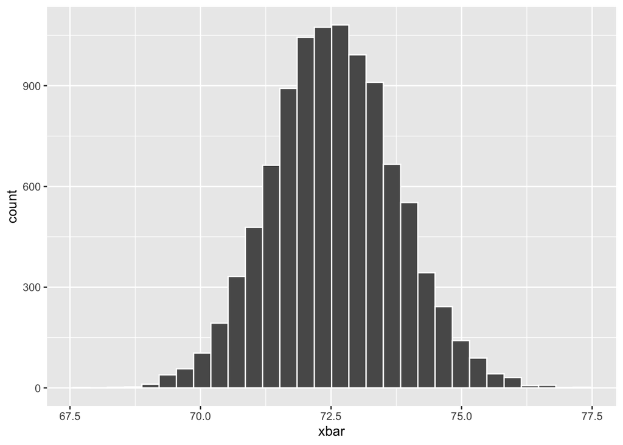

```r
n <- 100
samples <- rep_sample_n(nhanes, n,
                        replace = TRUE,
                        reps = 10000)

sample_stats <- samples %>%
  group_by(replicate) %>%
  summarize(xbar = mean(Pulse),
            s = sd(Pulse))

ggplot(sample_stats, aes(x = xbar)) +
  geom_histogram(color = "white")
```

7. Write code that utilizes the simulated values to investigate what proportion of simulated values fall in the critical region. *Hint: create a new variable that computes the t-statistic for each $\bar{x}$ as well as an indicator variable for whether the t-statistic falls in the critical region.* Comment on what you find. Keep your answer to 6d in mind.
8. Still considering the hypothesis test $H_0: \mu = 72.57$ vs. $H_A: \mu \neq 72.57$ and your current set of simulations: how often do you expect to get a p-value < 0.05? Why? Will p-value < 0.05 lead to a correct or incorrect conclusion to the hypothesis test in this case?
9. What type of error were #7 & 8 concerned with? Explain. If you wanted to reduce the probability of this error, what would you do? Explain.

## Further exploration (to read + reflect only)

The following code computes the p-value for each random sample in the simulations.

```r
alpha <- 0.05
n <- 100

sample_stats <- sample_stats %>%
  mutate(T = (xbar - mu)/(s/sqrt(n)),
         p_value = 2*pt(abs(T), n - 1, lower.tail = FALSE))
```

Recall that when $H_0$ is true, rejecting $H_0$ results in a Type I error. We control the Type I error by choosing $\alpha$; that is, we choose our rejection region such that $P(\text{Reject } H_0 | H_0 \text{ is true}) = \alpha$. For example, if we choose $\alpha = 0.1$, we will commit a Type I error 10% of the time.

The following code demonstrates this for the `nhanes` example. Recall that we are working with $H_0 = 72.57$ which we happen to know is true. Therefore we want to look at how often we obtained a random sample that would result in erroneously rejecting $H_0$, for various levels of $\alpha$. We first create a vector of possible $\alpha$ values (from 0 to 1). We then initialize an empty vector called `reject_probability` that we will fill in iteratively via a `for loop`. Recall that we reject $H_0$ if p-value < $\alpha$. Therefore, inside the for loop, we calculate for rejection probability for a particular value of $\alpha$ by computing the proportion of p-values in `sample_stats` that were less than $\alpha$.

```r
alpha_values <- seq(from = 0, to = 1, by = 0.01)

reject_probability <- c()

for(i in 1:length(alpha_values)){
  alpha <- alpha_values[i]
  reject_probability[i] <- sum(sample_stats$p_value < alpha)/nrow(sample_stats)
}
```

We can combine these results into a data frame for plotting. The graph demonstrates that the probability of rejecting $H_0$ (when it’s true) is equal to $\alpha$, as guaranteed by the mathematical theory.

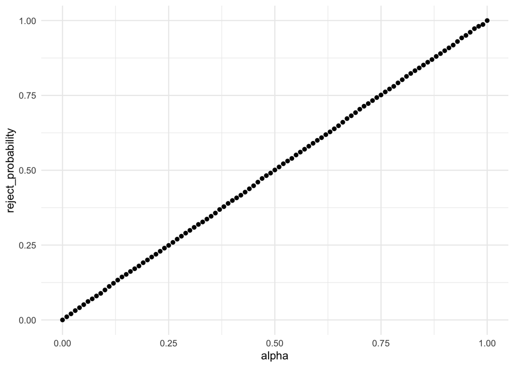

```r
results <- data.frame(alpha = alpha_values,
                      reject_probability = reject_probability)

ggplot(results, aes(x = alpha, y = reject_probability)) +
  geom_point() +
  theme_minimal()
```

The reason this works is because when the null hypothesis is true, p-values follow a uniform distribution on the interval 0 to 1. Recall that the probability that a $U(0,1)$ random variable is less than some constant (also between 0 and 1), is equal to that constant. In other words, because p-values are uniformly distributed, $P(p\_value < \alpha) = \alpha$, where the p-value is the random variable and $\alpha$ is the constant. The following visualization confirms that the p-values for our analysis are uniformly distributed.

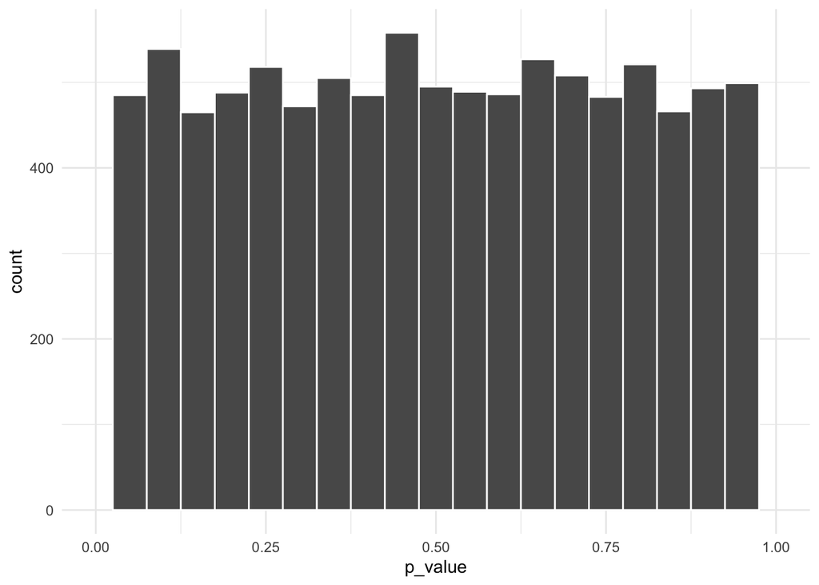

```r
ggplot(sample_stats, aes(x = p_value)) +
  geom_histogram(color = "white", binwidth = 0.05) +
  theme_minimal() +
  xlim(0,1)
```

### Proof that $p_v \sim U(0,1)$ when $H_0$ is true

The proof that p-values are uniformly distributed random variables under $H_0$ is very similar to a proof you saw in 361 involving cdfs.

Under the null hypothesis, a test statistic $T$ is a random variable that has a pdf (e.g. standard normal distribution, t-distribution, etc). Let’s call the pdf $f(t)$ and the corresponding cdf $F(t)$. Recall that a cdf is defined as $F(t) = P(T < t)$.

Let’s denote a p-value as $p_v$ (to distinguish it from the $p$ notation for a population proportion). Note that a p-value can be defined as $p_v = P(T > t)$. That is, a p-value is the probability that the test statistic exceeds some cut-off value, $t$. We can re-write $p_v = 1 - P(T < t) = 1-F(t)$. Note that $p_v$ is a random variable because it is a function of the random variable $T$. We are going to prove that $p_v \sim U(0,1)$ by first proving two Lemmas:

#### Lemma 1:

If $T$ is a random variable with cdf $F(\cdot)$, then $F(T) \sim U(0,1)$

#### Lemma 2:

If $U \sim U(0,1)$, then $1 - U$ is also $U(0,1)$.

#### Lemma 1 Proof:

Recall that if $X \sim U(0,1)$, its cdf is given by $P(X < x) = x$.

Define $Y = F(T)$ to be a random variable. We can express the cdf of $Y$ as $P(Y < y) = P(F(T) < y)$. Since $F(\cdot)$ is a cdf, it is monotonically increasing, and therefore has an inverse. Therefore:

$$\begin{aligned}
P(Y < y) &= P(F(T) < y) \\
&= P(F^{-1}(F(T)) < F^{-1}(y)) \\
&= P(T < F^{-1}(y)) \\
&= F(F^{-1}(y)) \\
&= y
\end{aligned}$$

Note that the second to last step is true because $P(T < F^{-1}(y))$ is simply the cdf of T evaluated at $F^{-1}(y)$. Therefore, since $P(Y < y) = y$ we have proved that $Y = F(T) \sim U(0,1)$.

#### Lemma 2 Proof:

Let $U \sim U(0,1)$ and define $W = 1-U$ to be another random variable. We can express the cdf of $W$ as $F(W) = P(W < w)$. If we can show this expression is equal to $w$, we will have shown that $W \sim U(0,1)$.

$$\begin{aligned}
P(W < w) &= P(1 - U < w) \\
&= P(1 - w < U)\\
&= P(U>1-w)\\
&=1-P(U < 1-w)\\
&=1-(1-w) \\
&= w
\end{aligned}$$

#### P-value $\sim U(0,1)$ under $H_0$ Proof

Therefore, since a p-value is defined as $p_v = P(T > t) = 1 - F(t)$, by Lemma 1, this is equivalent to 1 minus a uniform random variable, which by Lemma 2 is itself $U(0,1)$. Therefore, $p_v \sim U(0,1)$, which is what gives $P(p_v < \alpha) = \alpha$.

## Submission

Once you have completed all Exercises and written up your results in the Template .Rmd provided, take about 5-10 minutes to respond to the reflection prompts (RP) at the top of the Template:

- (RP1): *What were the main concepts covered in this assignment?*
- (RP2): *What’s one thing you understand better after completing these problems?*
- (RP3): *What problems gave you the most trouble? What was difficult about them/where did you get stuck?*
- (RP4): *What questions and/or reflections do you have regarding the Further Exploration demos and proofs?*

Knit your document one final time, then upload your .html file to Problem Set 05 on Canvas.

## Grading (50pts)

| Component | Points |
| --- | --- |
| RP1 | 5 |
| RP2 | 5 |
| RP3 | 5 |
| RP4 | 5 |
| Formatting & Clarity | 5 |
| Exercise completion | 25 |